# Shifting Baselines and Changepoint Analysis

Marc Los Huertos

EA030 · Compiled 2026-04-14

EA030 — Field & Lab Activities — A12

# Shifting Baselines & Changepoint Analysis

**Prof. Marc Los Huertos** • Pomona College

← Back to RTricks

Background Setup Offline Detection Variance Shifts Sequential Detection Real Data Exercises

By the end of this module you will be able to

1. Explain the shifting baseline problem and why it matters for long-term environmental monitoring.
2. Detect mean shifts in historical data using AMOC and PELT via the `changepoint` package.
3. Detect changes in variance using `cpt.var()` and interpret their ecological significance.
4. Apply sequential CUSUM monitoring and the `strucchange` package to test for structural breaks.
5. Choose the right penalty (AIC, BIC, MBIC) for a detection task and justify that choice.

> **What this module covers.** Environmental systems rarely stay put. Stream temperatures creep upward over decades, salmon populations collapse to a new lower equilibrium, droughts push groundwater down and keep it there. Standard statistics assume a stable reference state. This module teaches you to detect the moments when that reference permanently shifts, using both offline retrospective analysis and sequential monitoring tools.

## 1. Background

### 1.1 What is a baseline?

A **baseline** is the expected background state of a system against which current conditions are compared. Baselines are not fixed facts of nature — they are constructed reference periods, and they shift.

**📌 Shifting baseline syndrome** Fisheries biologist Daniel Pauly coined this term in 1995. Each generation of scientists calibrates “normal” to the ecosystem state they first encountered. Scientists starting in the 1950s defined healthy cod stocks by 1950s abundance; those starting in the 1980s accepted the already-depleted state as normal. The cumulative loss becomes invisible to any single generation.

### 1.2 What is a changepoint?

A **changepoint** is a time index $\tau$ at which a statistical property — mean, variance, or both — undergoes an abrupt shift:

$$X_t \sim \begin{cases}
\mathcal{N}(\mu_1,\, \sigma_1^2) & t \leq \tau \\
\mathcal{N}(\mu_2,\, \sigma_2^2) & t > \tau
\end{cases}$$

This is distinct from a gradual trend. Mann-Kendall detects trends; changepoint analysis detects **discrete jumps**.

**⚠️ Changepoints vs. trends** A gradual upward trend and a sudden step change can look similar in a raw time plot. Choose your tool based on which kind of shift is ecologically plausible for your system.

## 2. Setup

```r
library(changepoint)   # AMOC, PELT (cpt.mean, cpt.var, cpt.meanvar)
library(strucchange)   # CUSUM, breakpoints with confidence intervals
library(ggplot2)
library(dplyr)
library(knitr)
```

### 2.1 Simulated stream temperature data

We use a synthetic dataset mimicking Sierra Nevada foothill stream temperatures during and after the 2012–2017 California drought:

- **Phase 1** (months 1–120): Cool pre-drought baseline, mean 14 deg C, SD 0.8
- **Phase 2** (months 121–204): Drought, mean rises to 18.2 deg C, SD 0.9
- **Phase 3** (months 205–288): Partial recovery to 16 deg C, but SD = 2.1 (flashier hydrology)

```r
set.seed(2024)
n1 <- 120; n2 <- 84; n3 <- 84
N  <- n1 + n2 + n3

temp  <- c(
  rnorm(n1, mean = 14.0, sd = 0.8),
  rnorm(n2, mean = 18.2, sd = 0.9),
  rnorm(n3, mean = 16.1, sd = 2.1)
)
dates     <- seq(as.Date("2000-01-01"), by = "month", length.out = N)
true_cpts <- c(n1, n1 + n2)
stream_df <- data.frame(date = dates, temp = temp)
```

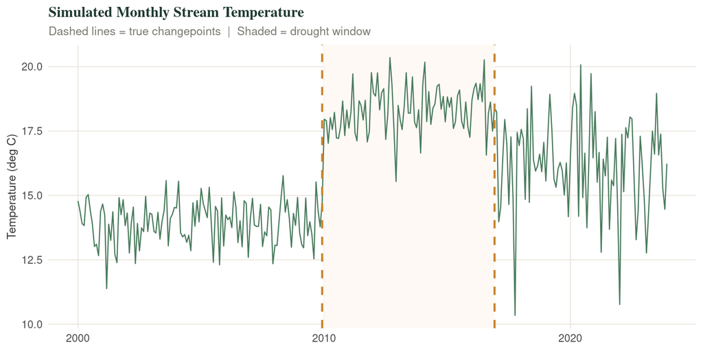

Simulated monthly stream temperature. True changepoints are dashed amber lines; the shaded band marks the simulated drought window.

```r
ggplot(stream_df, aes(x = date, y = temp)) +
  annotate("rect",
    xmin = dates[n1 + 1], xmax = dates[n1 + n2],
    ymin = -Inf, ymax = Inf, fill = "#fff8f4", alpha = 0.9) +
  geom_line(colour = col_fern, linewidth = 0.45) +
  geom_vline(xintercept = dates[true_cpts],
             linetype = "dashed", colour = col_amber, linewidth = 0.8) +
  labs(title    = "Simulated Monthly Stream Temperature",
       subtitle = "Dashed lines = true changepoints  |  Shaded = drought window",
       x = NULL, y = "Temperature (deg C)")
```

## 3. Offline Changepoint Detection

Offline methods work on the complete historical record. They find the set of changepoints that minimises total within-segment cost plus a penalty for model complexity.

### 3.1 AMOC — At Most One Change

AMOC evaluates every possible single split and picks the best one. Useful when you expect exactly one regime shift.

```r
m_amoc <- cpt.mean(temp, method = "AMOC")

cat("AMOC changepoint at index:", cpts(m_amoc), "\n")
```

```
## AMOC changepoint at index: 120
```

```r
cat("  =>", format(dates[cpts(m_amoc)], "%b %Y"), "\n")
```

```
##   => Dec 2009
```

```r
cat("Segment means:", round(param.est(m_amoc)$mean, 2), "deg C\n")
```

```
## Segment means: 13.96 17.25 deg C
```

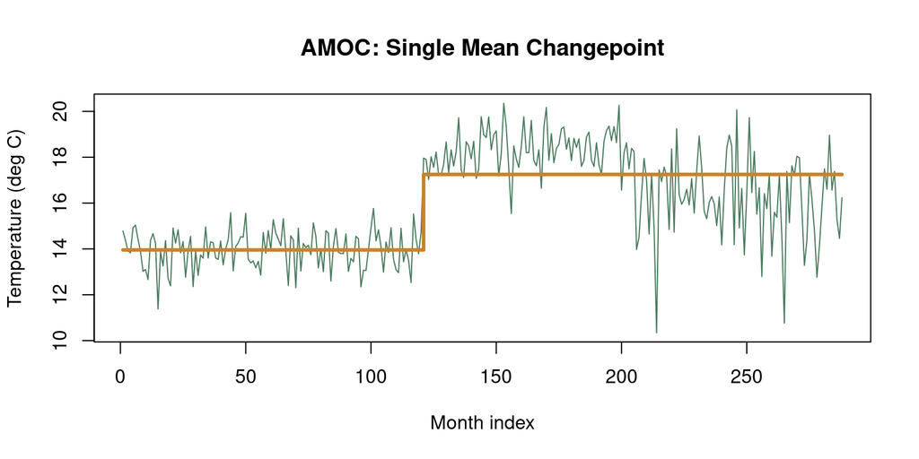

AMOC detects the single most significant mean shift — the large drought-onset step. It cannot detect a second changepoint by design.

```r
plot(m_amoc,
     main = "AMOC: Single Mean Changepoint",
     ylab = "Temperature (deg C)", xlab = "Month index",
     col  = col_fern, cpt.col = col_amber,
     cpt.width = 3, mean.col = col_forest)
```

### 3.2 PELT — Multiple Changepoints

PELT (Pruned Exact Linear Time) finds the globally optimal set of changepoints efficiently. The key user decision is the **penalty**:

Penalty options for PELT mean changepoint detection.

| Penalty | Behavior | Use |
| --- | --- | --- |
| AIC | Most permissive — more changepoints | Exploratory, dense sensor data |
| BIC | Balanced — standard default | Most environmental records |
| MBIC | Conservative — fewer false positives | High cost of false alarms |

```r
m_pelt <- cpt.mean(temp, method = "PELT", penalty = "BIC")

cat("PELT (BIC) changepoints:", cpts(m_pelt), "\n")
```

```
## PELT (BIC) changepoints: 120 205 213 214 255 264 265
```

```r
cat("  =>", format(dates[cpts(m_pelt)], "%b %Y"), "\n")
```

```
##   => Dec 2009 Jan 2017 Sep 2017 Oct 2017 Mar 2021 Dec 2021 Jan 2022
```

```r
cat("Segment means:", round(param.est(m_pelt)$mean, 2), "deg C\n")
```

```
## Segment means: 13.96 18.32 15.84 10.34 16.67 15.4 10.76 16.12 deg C
```

```r
cat("True changepoints at months:", true_cpts, "\n")
```

```
## True changepoints at months: 120 204
```

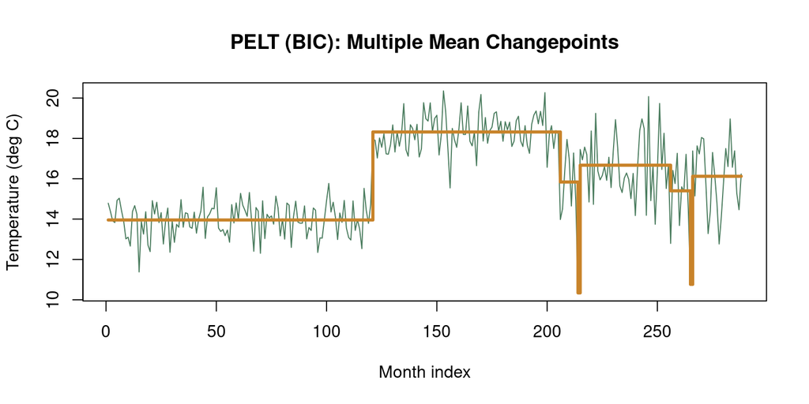

```r
plot(m_pelt,
     main = "PELT (BIC): Multiple Mean Changepoints",
     ylab = "Temperature (deg C)", xlab = "Month index",
     col  = col_fern, cpt.col = col_amber,
     cpt.width = 3, mean.col = col_forest)
```

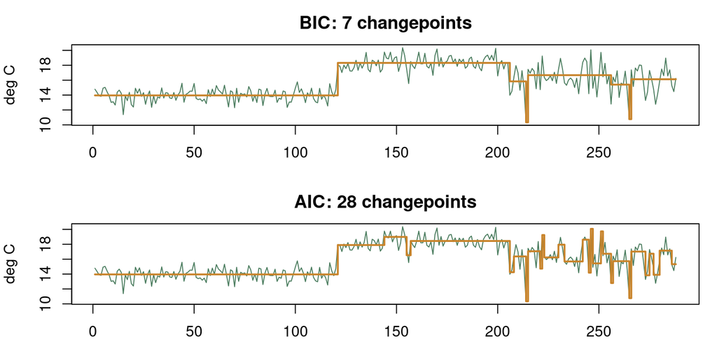

AIC vs BIC penalty comparison. AIC is more permissive and may over-segment the volatile post-drought phase.

```r
m_aic <- cpt.mean(temp, method = "PELT", penalty = "AIC")

par(mfrow = c(2, 1), mar = c(3, 4, 2.5, 1))
plot(m_pelt, main = paste("BIC:", length(cpts(m_pelt)), "changepoints"),
     ylab = "deg C", col = col_fern, cpt.col = col_amber,
     cpt.width = 2, mean.col = col_forest, xlab = "")
plot(m_aic,  main = paste("AIC:", length(cpts(m_aic)),  "changepoints"),
     ylab = "deg C", col = col_fern, cpt.col = col_amber,
     cpt.width = 2, mean.col = col_forest, xlab = "Month index")
```

```r
par(mfrow = c(1, 1))
```

**💡 Which penalty to use?** Start with BIC. Use AIC for dense exploratory work. Use MBIC when false alarms carry regulatory costs. Always report and justify your choice.

## 4. Variance Shifts

The post-drought phase has the same rough mean as recovery, but much higher variance — the stream is flashier. This matters ecologically:

**Why variance shifts matter** Mean = 16 deg C, SD = 0.9: temperatures exceed 18 deg C less than 2% of days. Mean = 16 deg C, SD = 2.1: temperatures exceed 18 deg C roughly 17% of days — above the thermal tolerance limit of many cold-water fish.

```r
m_var <- cpt.var(temp, method = "PELT", penalty = "BIC")

cat("Variance changepoint(s):", cpts(m_var), "\n")
```

```
## Variance changepoint(s):
```

```r
cat("  =>", format(dates[cpts(m_var)], "%b %Y"), "\n")
```

```
##   =>
```

```r
cat("Segment SDs:", round(sqrt(param.est(m_var)$variance), 2), "deg C\n")
```

```
## Segment SDs: 2.18 deg C
```

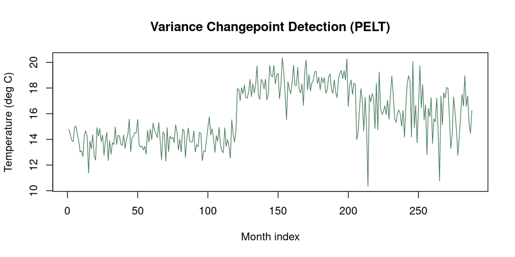

```r
plot(m_var,
     main = "Variance Changepoint Detection (PELT)",
     ylab = "Temperature (deg C)", xlab = "Month index",
     col  = col_fern, cpt.col = col_amber, cpt.width = 3)
```

```r
m_mv <- cpt.meanvar(temp, method = "PELT", penalty = "BIC")

cat("Mean+variance changepoints:", cpts(m_mv), "\n")
```

```
## Mean+variance changepoints: 120 205
```

```r
cat("Segment means:", round(param.est(m_mv)$mean, 2), "\n")
```

```
## Segment means: 13.96 18.32 16.15
```

```r
cat("Segment SDs:  ", round(sqrt(param.est(m_mv)$variance), 2), "\n")
```

```
## Segment SDs:   0.82 0.88 1.79
```

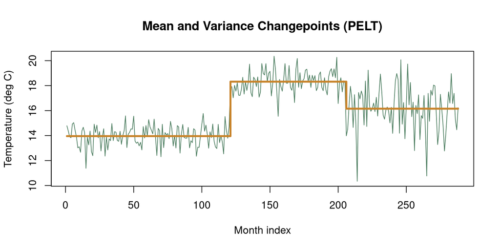

Joint mean-and-variance changepoint detection. A shift in either the mean or the variance triggers a new changepoint.

```r
plot(m_mv,
     main = "Mean and Variance Changepoints (PELT)",
     ylab = "Temperature (deg C)", xlab = "Month index",
     col  = col_fern, cpt.col = col_amber,
     cpt.width = 3, mean.col = col_forest)
```

## 5. Sequential Detection with strucchange

Offline methods need all the data at once. The `strucchange` package provides two complementary tools for detecting and locating breaks: a sequential fluctuation test and optimal breakpoints with timing CIs.

### 5.1 CUSUM fluctuation process

The OLS-CUSUM process accumulates deviations from a fitted intercept model over time. Breaching the critical boundary signals structural change.

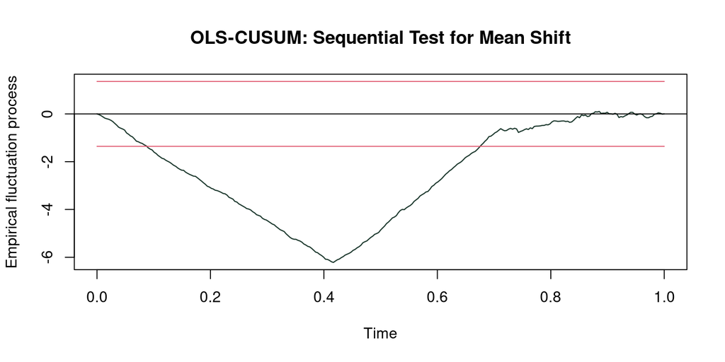

```r
efp_fit <- efp(temp ~ 1, type = "OLS-CUSUM")
plot(efp_fit,
     main = "OLS-CUSUM: Sequential Test for Mean Shift",
     ylab = "Empirical fluctuation process",
     col  = col_forest, lwd  = 1.2)
```

```r
sc <- sctest(efp_fit)
cat(sprintf("OLS-CUSUM:  statistic = %.3f,  p-value = %.5f\n",
            sc$statistic, sc$p.value))
```

```
## OLS-CUSUM:  statistic = 6.217,  p-value = 0.00000
```

### 5.2 Optimal breakpoints with confidence intervals

`breakpoints()` finds the globally optimal breakpoints and — unlike `changepoint` — reports **95% confidence intervals on timing**. Knowing whether a shift occurred in 2009 vs 2013 often matters for attributing cause to a specific event or policy.

```r
# Step 1: fit the full breakpointsfull object
bp_full <- breakpoints(temp ~ 1)

# Step 2: select optimal number of breakpoints (minimises BIC)
bp_opt  <- breakpoints(bp_full)

# Step 3: confidence intervals come from the breakpointsfull object
ci      <- confint(bp_full)

cat("Optimal breakpoint indices:", bp_opt$breakpoints, "\n")
```

```
## Optimal breakpoint indices: 120 205
```

```r
cat("  =>", format(dates[bp_opt$breakpoints], "%b %Y"), "\n")
```

```
##   => Dec 2009 Jan 2017
```

```r
cat("True changepoints at months:", true_cpts, "\n")
```

```
## True changepoints at months: 120 204
```

```r
cat("\n95% CI on breakpoint timing (month indices):\n")
```

```
##
## 95% CI on breakpoint timing (month indices):
```

```r
print(ci$confint)
```

```
##   2.5 % breakpoints 97.5 %
## 1   119         120    121
## 2   196         205    207
```

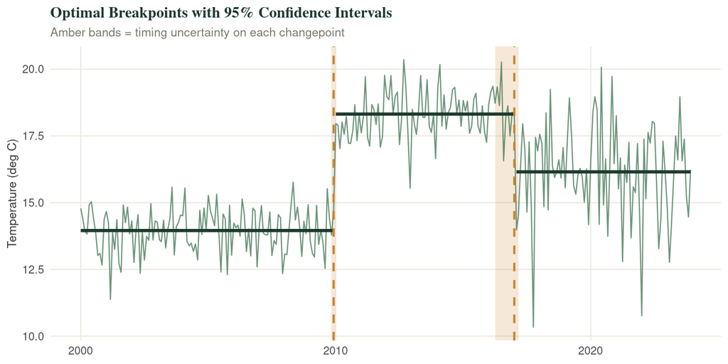

Stream temperature with breakpoints and 95% confidence intervals. Amber bands mark the timing uncertainty; horizontal lines show segment means.

```r
# Segment means via breakfactor
bf        <- breakfactor(bp_opt)
seg_means <- coef(lm(temp ~ bf - 1))

ci_mat  <- ci$confint
bp_idx  <- c(0, bp_opt$breakpoints, N)

mean_df <- data.frame(
  xmin = dates[bp_idx[-length(bp_idx)] + 1],
  xmax = dates[bp_idx[-1]],
  yval = seg_means
)
ci_df <- data.frame(
  xlo = dates[pmax(1, ci_mat[, 1])],
  xhi = dates[pmin(N, ci_mat[, 3])]
)

ggplot(stream_df, aes(x = date, y = temp)) +
  geom_rect(data = ci_df,
            aes(xmin = xlo, xmax = xhi, ymin = -Inf, ymax = Inf),
            inherit.aes = FALSE, fill = col_amber, alpha = 0.18) +
  geom_line(colour = col_fern, linewidth = 0.45, alpha = 0.8) +
  geom_segment(data = mean_df,
               aes(x = xmin, xend = xmax, y = yval, yend = yval),
               colour = col_forest, linewidth = 1.2) +
  geom_vline(xintercept = dates[ci_mat[, 2]],
             linetype = "dashed", colour = col_amber, linewidth = 0.8) +
  labs(title    = "Optimal Breakpoints with 95% Confidence Intervals",
       subtitle = "Amber bands = timing uncertainty on each changepoint",
       x = NULL, y = "Temperature (deg C)")
```

### 5.3 The shifting baseline problem in sequential monitoring

A CUSUM chart uses a fixed reference mean. Once the baseline shifts, every observation in the new regime accumulates as a “deviation” from the old reference — the statistic never resets and becomes meaningless.

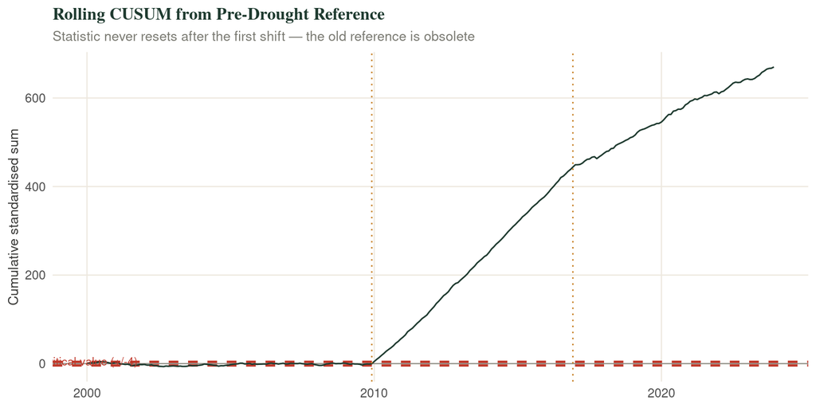

Rolling CUSUM from the pre-drought reference mean. The statistic keeps rising indefinitely after the first shift because the reference is no longer valid — this is the shifting baseline problem in action.

```r
ref_mean <- mean(temp[1:n1])
ref_sd   <- sd(temp[1:n1])
cusum_df <- data.frame(
  date  = dates,
  cusum = cumsum((temp - ref_mean) / ref_sd)
)

ggplot(cusum_df, aes(x = date, y = cusum)) +
  geom_hline(yintercept = c(-4, 4), linetype = "dashed",
             colour = "#c0392b", linewidth = 0.8) +
  geom_hline(yintercept = 0, colour = col_dust, linewidth = 0.3) +
  geom_line(colour = col_forest, linewidth = 0.5) +
  geom_vline(xintercept = dates[true_cpts],
             linetype = "dotted", colour = col_amber) +
  annotate("text", x = min(dates) + 30, y = 4.8,
           label = "Critical value (+/-4)", colour = "#c0392b", size = 2.8) +
  labs(title    = "Rolling CUSUM from Pre-Drought Reference",
       subtitle = "Statistic never resets after the first shift — the old reference is obsolete",
       x = NULL, y = "Cumulative standardised sum")
```

**⚠️ Operational fix** Reset the reference mean after each confirmed changepoint. Otherwise your monitoring system perpetually alarms on the new normal.

## 6. Real Environmental Data: Nile River Flow

R’s built-in `Nile` dataset records annual discharge at Aswan 1871–1970. A documented structural break near 1899 reflects construction of the Aswan Low Dam and upstream land-use change.

```r
data(Nile)
nile_df <- data.frame(year = as.numeric(time(Nile)),
                      discharge = as.numeric(Nile))

nile_pelt <- cpt.mean(as.numeric(Nile), method = "PELT", penalty = "BIC")
cp_year   <- 1871 + cpts(nile_pelt) - 1
means_n   <- param.est(nile_pelt)$mean

cat("PELT changepoint year:", cp_year, "\n")
```

```
## PELT changepoint year: 1871 1872 1873 1874 1876 1877 1878 1879 1880 1881 1882 1883 1884 1885 1886 1887 1888 1889 1890 1891 1892 1893 1894 1895 1896 1897 1898 1899 1900 1901 1902 1903 1904 1905 1906 1907 1908 1909 1910 1911 1912 1913 1914 1915 1916 1917 1918 1919 1920 1921 1922 1924 1925 1926 1927…
```

```r
cat("Segment means:", round(means_n), "x 10^8 m^3\n")
```

```
## Segment means: 1120 1160 963 1210 1160 813 1230 1370 1140 995 935 1110 994 1020 960 1180 799 958 1140 1100 1210 1150 1250 1260 1220 1030 1100 774 840 874 694 940 833 701 916 692 1020 1050 969 831 726 456 824 702 1120 1100 832 764 821 768 845 863 698 845 744 796 1040 759 781 865 845 944 984 897 82…
```

```r
cat("Drop:", round(abs(diff(means_n))), "x 10^8 m^3",
    sprintf("(%.0f%%)\n", 100 * abs(diff(means_n)) / means_n[1]))
```

[output not shown]

[output cut: 41 more lines]

```
##  (12%)
##  (6%)
##  (17%)
##  (11%)
##  (5%)
##  (14%)
##  (18%)
##  (10%)
##  (0%)
##  (24%)
##  (23%)
##  (15%)
##  (15%)
##  (18%)
##  (2%)
```

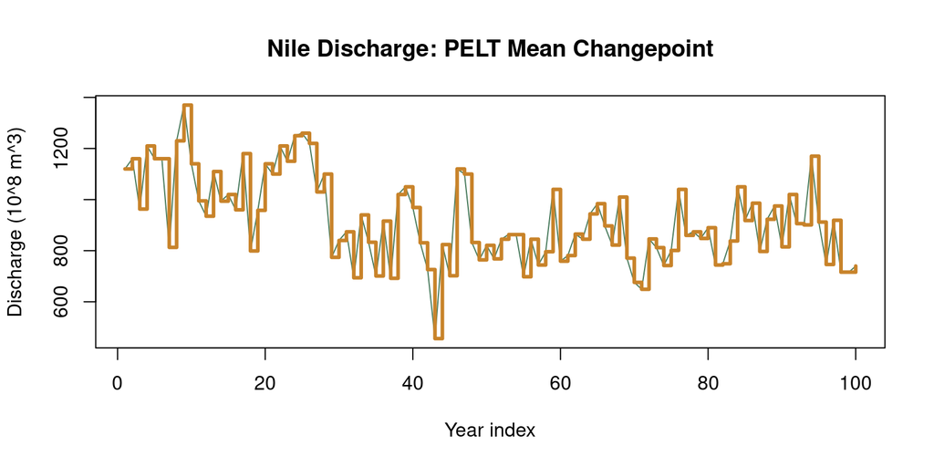

```r
plot(nile_pelt,
     main = "Nile Discharge: PELT Mean Changepoint",
     ylab = "Discharge (10^8 m^3)", xlab = "Year index",
     col  = col_fern, cpt.col = col_amber,
     cpt.width = 3, mean.col = col_forest)
```

```r
# strucchange: breakpoints with 95% CI on timing
# confint() must be called on the breakpointsfull object
nile_bp_full <- breakpoints(as.numeric(Nile) ~ 1)
nile_bp_opt  <- breakpoints(nile_bp_full)
nile_ci      <- confint(nile_bp_full)

bp_yr <- 1871 + nile_bp_opt$breakpoints - 1
ci_lo <- 1871 + nile_ci$confint[1, 1] - 1
ci_hi <- 1871 + nile_ci$confint[1, 3] - 1

cat(sprintf("strucchange breakpoint: %d  (95%% CI: %d - %d)\n",
            bp_yr, ci_lo, ci_hi))
```

```
## strucchange breakpoint: 1898  (95% CI: 1895 - 1902)
```

```r
cat("CI width:", ci_hi - ci_lo, "years\n")
```

```
## CI width: 7 years
```

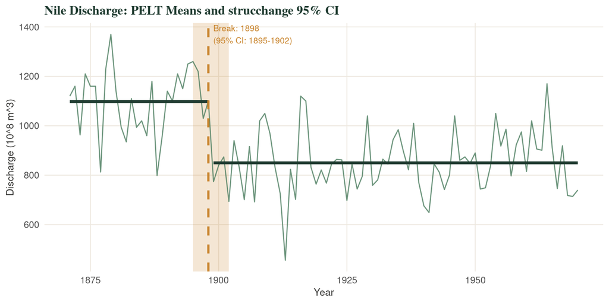

Nile discharge with segment means and 95% CI band on the changepoint year. The narrow CI supports attributing the break to the Aswan Low Dam construction.

```r
nile_bf  <- breakfactor(nile_bp_opt)
nile_mu  <- coef(lm(as.numeric(Nile) ~ nile_bf - 1))
nile_idx <- c(0, nile_bp_opt$breakpoints, length(Nile))

nile_mean_df <- data.frame(
  xmin = 1871 + nile_idx[-length(nile_idx)],
  xmax = 1871 + nile_idx[-1] - 1,
  yval = nile_mu
)

ggplot(nile_df, aes(x = year, y = discharge)) +
  annotate("rect", xmin = ci_lo, xmax = ci_hi,
           ymin = -Inf, ymax = Inf, fill = col_amber, alpha = 0.2) +
  geom_line(colour = col_fern, linewidth = 0.5, alpha = 0.8) +
  geom_segment(data = nile_mean_df,
               aes(x = xmin, xend = xmax, y = yval, yend = yval),
               colour = col_forest, linewidth = 1.3) +
  geom_vline(xintercept = bp_yr, colour = col_amber,
             linetype = "dashed", linewidth = 1) +
  annotate("text", x = bp_yr + 1, y = 1370,
           label = sprintf("Break: %d\n(95%% CI: %d-%d)", bp_yr, ci_lo, ci_hi),
           hjust = 0, size = 2.8, colour = col_amber) +
  labs(title    = "Nile Discharge: PELT Means and strucchange 95% CI",
       x = "Year", y = "Discharge (10^8 m^3)")
```

#### 🔑 Key Takeaways

- **Shifting baselines** accumulate silently — statistical detection makes them explicit and quantifiable.
- **AMOC** finds one break; **PELT** finds the globally optimal set in O(n) time.
- **Penalty choice** (AIC / BIC / MBIC) controls sensitivity vs false-alarm rate — always report it.
- **Variance shifts** are ecologically important even when the mean is stable — use `cpt.var()`.
- **strucchange** adds 95% CIs on changepoint timing; call `confint()` on the `breakpointsfull` object, not on the result of `breakpoints(breakpointsfull)`.
- Sequential CUSUM must be **re-referenced** after each confirmed shift or it becomes meaningless.

✏️ Practice Exercises

Exercise 1 — Ozone changepoints

Load `airquality` and remove rows with missing `Ozone`. Apply PELT with BIC penalty. (a) How many changepoints are detected? (b) Convert indices to calendar dates. (c) Do the breaks correspond to a meteorological explanation?

**Show solution**

```
data(airquality)
ozone <- airquality[!is.na(airquality$Ozone), ]
m <- cpt.mean(ozone$Ozone, method = "PELT", penalty = "BIC")
cpts(m)
ozone$date <- as.Date(paste(1973, ozone$Month, ozone$Day, sep = "-"))
ozone$date[cpts(m)]
plot(m, ylab = "Ozone (ppb)", main = "Ozone changepoints 1973")
```

A changepoint typically appears around late June, separating the cool low-ozone spring from hot high-ozone midsummer. This marks the onset of photochemical production driven by higher temperatures and longer days.

Exercise 2 — Variance shift in PM2.5

Simulate two years of daily PM2.5: Year 1 mean = 10, SD = 2; Year 2 mean = 10, SD = 8 (wildfire smoke). Use `set.seed(42)`. (a) Does `cpt.mean()` find a changepoint? (b) Does `cpt.var()`? (c) What does this imply for monitoring standards based on annual means?

**Show solution**

```
set.seed(42)
pm25 <- c(rnorm(365, 10, 2), rnorm(365, 10, 8))
m_mean <- cpt.mean(pm25, method = "PELT", penalty = "BIC")
m_var  <- cpt.var(pm25,  method = "PELT", penalty = "BIC")
cat("Mean cpts:", cpts(m_mean), "\n")
cat("Variance cpts:", cpts(m_var), "\n")
```

`cpt.mean()` finds nothing. `cpt.var()` detects the shift near day 365. Even with the same annual mean, the high-variance year has far more days above the 35 ug/m3 NAAQS threshold — health risk is driven by peak events, not averages alone.

Exercise 3 — Penalty sensitivity on Nile data

Run PELT on the Nile dataset with “AIC”, “BIC”, and “MBIC” penalties. (a) How many changepoints does each detect? (b) Is the primary break year consistent? (c) Which penalty would you use in a regulatory report?

**Show solution**

```
data(Nile)
for (pen in c("AIC", "BIC", "MBIC")) {
  m   <- cpt.mean(as.numeric(Nile), method = "PELT", penalty = pen)
  yrs <- 1871 + cpts(m) - 1
  cat(pen, ":", length(cpts(m)), "changepoint(s) at", yrs, "\n")
}
```

Exercise 4 — Confidence intervals on timing

Using the Nile dataset and `strucchange`, obtain a 95% CI on the breakpoint year. (a) How wide is the CI? (b) The Aswan Low Dam was completed in 1902. Does your CI include this year? (c) Why does CI width matter for causal attribution?

**Show solution**

```
library(strucchange)
data(Nile)
bp  <- breakpoints(as.numeric(Nile) ~ 1)   # breakpointsfull
bpo <- breakpoints(bp)                       # optimal selection
ci  <- confint(bp)                           # CI from breakpointsfull
cat("Year:", 1871 + bpo$breakpoints - 1, "\n")
cat("95% CI:", 1871 + ci$confint[c(1, 3)] - 1, "\n")
cat("Width:", diff(ci$confint[c(1, 3)]), "years\n")
```